# Instacart Visualizations

#### Department by Dependants

```python
#Group by dependants and department
trial=ords_prods_cust_dept.groupby(['department','dependants_flag']).size().unstack()
```

```python
#Sort
trial = trial.loc[trial.sum(axis=1).sort_values(ascending = True).index]
```

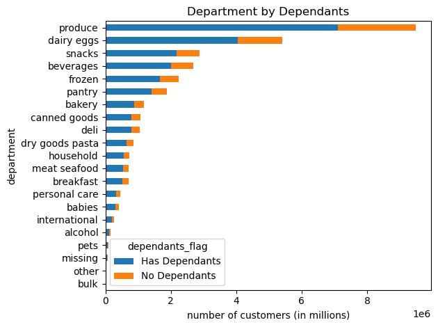

```python
#create bar graph
bar_trial = trial.plot.barh(stacked = True, title = 'Department by Dependants', xlabel = 'number of customers (in millions)')
plt.tight_layout()
```

Produce is the most popular department, followed by dairy & eggs.

There is no significant difference between dependants groups.

```python
#Export bar_trial
bar_trial.figure.savefig(os.path.join(path, '04 Analysis', 'Visualizations', 'bar_trial'))
```

### Other

#### Family Status Vs. Age

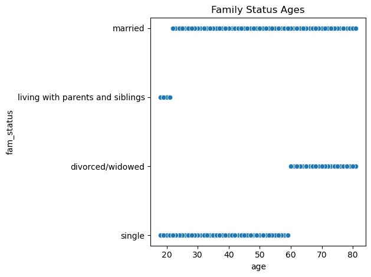

```python
scatter_age_fam = sns.scatterplot(x = 'age', y = 'fam_status',data = ords_prods_cust_dept)
plt.title('Family Status Ages')
plt.tight_layout()
```

According to this data:

married customers are between early 20s-80s

customers living with parents/siblings are teens-early 20s

customers who are divorced/widows are 60 and older

customers who are single are younger than 60

#### Income Vs. Age

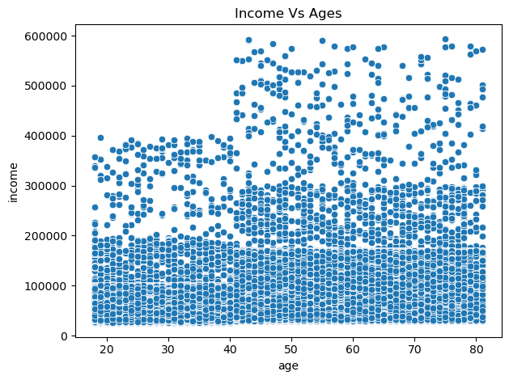

```python
scatter_age_income = sns.scatterplot(x = 'age', y = 'income',data = ords_prods_cust_dept)
plt.title('Income Vs Ages')
plt.tight_layout()
```

Most people across age groups make under 200k.

```python
#Export scatter_age_income
scatter_age_income.figure.savefig(os.path.join(path, '04 Analysis', 'Visualizations', 'scatter_age_income'))
```

### 7. Key Question 7 Visualizations: Region, Regional Expenditures, Regional Orders, Regional Departments

### Region

#### Customers in Each Region

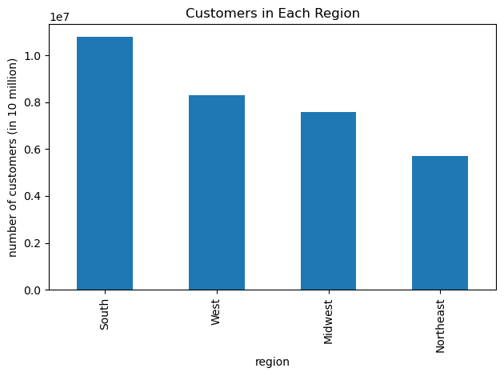

```python
#create bar graph
bar_region = ords_prods_cust_dept['region'].value_counts().plot.bar(stacked = True, title = 'Customers in Each Region', ylabel = 'number of customers (in 10 million)')
plt.tight_layout()
```

The south has the most customers and the Northeast has the fewest customers.

```python
#Export bar graph
bar_region.figure.savefig(os.path.join(path, '04 Analysis', 'Visualizations', 'bar_region'))
```

#### Customer Profile by Region

```python
#Group by customer profile and region
profile_region=ords_prods_cust_dept.groupby(['customer_profile','region']).size().unstack()
```

```python
#Sort
profile_region = profile_region.loc[profile_region.sum(axis=1).sort_values(ascending = True).index]
```

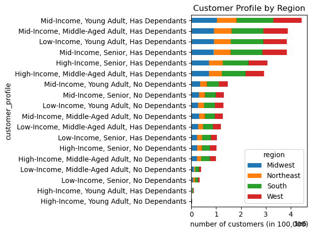

```python
#create bar graph
bar_profile_region = profile_region.plot.barh(stacked = True, title = 'Customer Profile by Region', xlabel = 'number of customers (in 100,000)')
plt.tight_layout()
```

Across all customer profiles, the proportions of customers are the same. This means there are no regional differences in customer income, age, and number of dependants.

```python
#Export profile_region
bar_profile_region.figure.savefig(os.path.join(path, '04 Analysis', 'Visualizations', 'bar_profile_region'))
```

#### Income by Region

```python
#Group by income_group and region
income_region=ords_prods_cust_dept.groupby(['region', 'income_group']).size().unstack()
```

```python
#Sort
income_region = income_region.loc[income_region.sum(axis=1).sort_values(ascending = True).index]
```

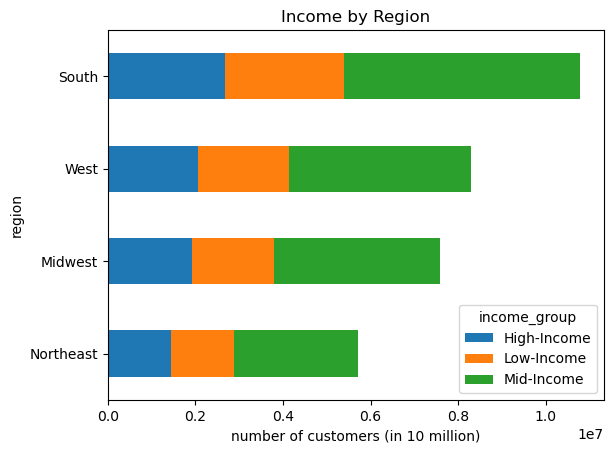

```python
#create bar graph
bar_income_region = income_region.plot.barh(stacked = True, title = 'Income by Region', xlabel = 'number of customers (in 10 million)')
```

The proportions of customers are the same. There are no regional differences in customer income.

```python
#Export bar_income_region
bar_income_region.figure.savefig(os.path.join(path, '04 Analysis', 'Visualizations', 'bar_income_region'))
```

#### Age by Region

```python
#Group by age_group and region
age_region=ords_prods_cust_dept.groupby(['region','age_group']).size().unstack()
```

```python
#Sort
age_region = age_region.loc[age_region.sum(axis=1).sort_values(ascending = True).index]
```

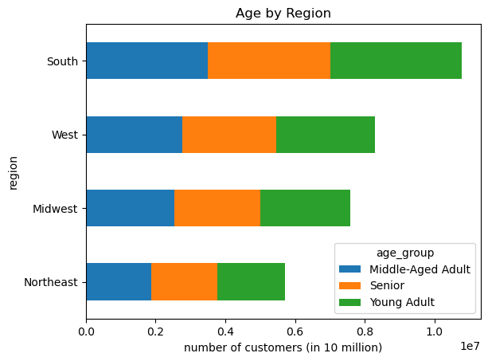

```python
#create bar graph
bar_age_region = age_region.plot.barh(stacked = True, title = 'Age by Region', xlabel = 'number of customers (in 10 million)')
```

The proportions of customers are the same. There are no regional differences in customer age.

```python
#Export bar_age_region
bar_age_region.figure.savefig(os.path.join(path, '04 Analysis', 'Visualizations', 'bar_age_region'))
```

#### Dependants by Region

```python
#Group by dependants_flag and region
dependants_region=ords_prods_cust_dept.groupby(['region', 'dependants_flag']).size().unstack()
```

```python
#Sort
dependants_region = dependants_region.loc[dependants_region.sum(axis=1).sort_values(ascending = True).index]
```

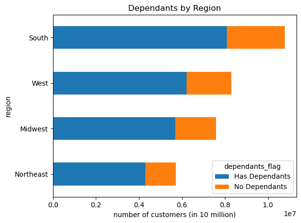

```python
#create bar graph
bar_dependants_region = dependants_region.plot.barh(stacked = True, title = 'Dependants by Region', xlabel = 'number of customers (in 10 million)')
```

The proportions of customers are the same. There are no regional differences in customer number of dependants.

#### Spending by Region

```python
#create crosstab to compare 'region' to 'spending'
regional_spending = pd.crosstab(ords_prods_cust_dept['region'], ords_prods_cust_dept['spending_flag'], dropna = False)
```

```python
regional_spending.to_clipboard
```

```
<bound method NDFrame.to_clipboard of spending_flag  High spender  Low spender
region
Midwest             2495774      5101551
Northeast           1874326      3848410
South               3547836      7244049
West                2720859      5572054>
```

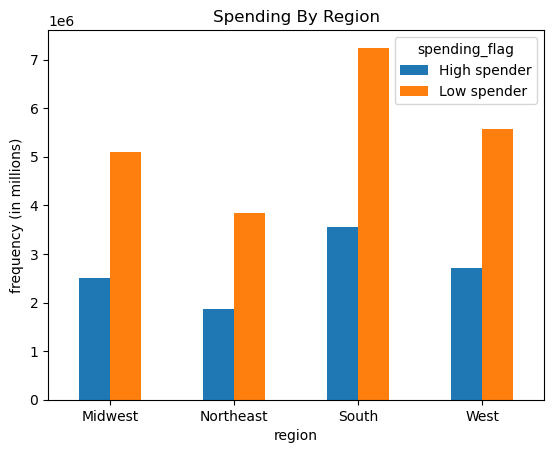

```python
#create bar graph showing spending trends across regions
regional_spending_bar = regional_spending.plot.bar(rot=0)
plt.title('Spending By Region')
plt.ylabel('frequency (in millions)')
```

The proportions of customers are the same. There are no regional differences in amount spent.

```python
#Export regional_spending_bar
regional_spending_bar.figure.savefig(os.path.join(path, '04 Analysis', 'Visualizations', 'regional_spending_bar'))
```

### Regional Expenditures

#### Regional Expenditures by Income Group

```python
#aggregating 'order_id' and 'prices' from sample
fam_revenue = ords_prods_cust_dept.groupby(['department', 'income_group','region'], as_index=False).agg({'order_id': 'count', 'prices': 'sum'})
fam_revenue.head(3)
```

|  | department | income_group | region | order_id | prices |
| --- | --- | --- | --- | --- | --- |
| 0 | alcohol | High-Income | Midwest | 9683 | 80089.1 |
| 1 | alcohol | High-Income | Northeast | 8483 | 70470.6 |
| 2 | alcohol | High-Income | South | 14380 | 120054.9 |

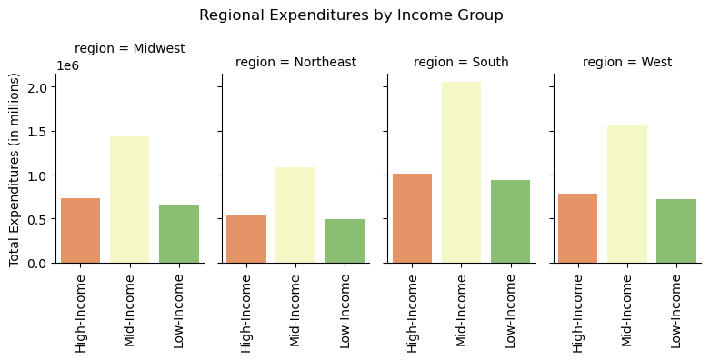

```python
### FacetGrid for fam_status and Revenue
fam_revenue = sns.FacetGrid(fam_revenue, col="region", height=4, aspect=.5,)
fam_revenue.map(sns.barplot, "income_group", "prices", palette='RdYlGn', order = ['High-Income', 'Mid-Income', 'Low-Income'], ci= None)

fam_revenue.set_xticklabels(rotation='vertical')
fam_revenue.set_axis_labels("", "Total Expenditures (in millions)")
fam_revenue.fig.suptitle("Regional Expenditures by Income Group")
fam_revenue.figure.subplots_adjust(top=.8)
plt.tight_layout()
```

There are no significant differences across regions in expenditures.

```python
#Export fam_revenue
fam_revenue.figure.savefig(os.path.join(path, '04 Analysis', 'Visualizations', 'fam_revenue'))
```

#### Regional Expenditures by Age

```python
#aggregating 'order_id' and 'prices' from sample
age_revenue = ords_prods_cust_dept.groupby(['department', 'age_group','region'], as_index=False).agg({'order_id': 'count', 'prices': 'sum'})
age_revenue.head(3)
```

|  | department | age_group | region | order_id | prices |
| --- | --- | --- | --- | --- | --- |
| 0 | alcohol | Middle-Aged Adult | Midwest | 11615 | 95083.6 |
| 1 | alcohol | Middle-Aged Adult | Northeast | 9337 | 76922.2 |
| 2 | alcohol | Middle-Aged Adult | South | 15387 | 125034.0 |

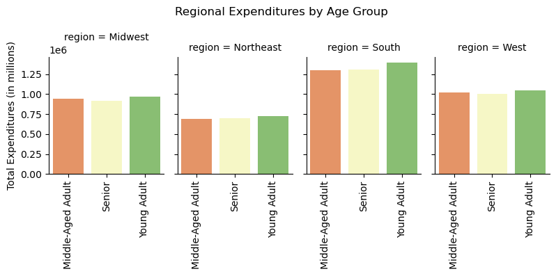

```python
### FacetGrid for age and Revenue
age_revenue = sns.FacetGrid(age_revenue, col="region", height=4, aspect=.5,)
age_revenue.map(sns.barplot, "age_group", "prices", palette='RdYlGn', ci= None)

age_revenue.set_xticklabels(rotation='vertical')
age_revenue.set_axis_labels("", "Total Expenditures (in millions)")
age_revenue.fig.suptitle("Regional Expenditures by Age Group")
age_revenue.figure.subplots_adjust(top=.8)
plt.tight_layout()
```

There are no significant differences across regions in expenditures.

```python
#Export age_revenue
age_revenue.figure.savefig(os.path.join(path, '04 Analysis', 'Visualizations', 'age_revenue2'))
```

#### Regional Expenditures by Dependants

```python
#aggregating 'order_id' and 'prices' from sample
dependants_revenue = ords_prods_cust_dept.groupby(['department', 'dependants_flag','region'], as_index=False).agg({'order_id': 'count', 'prices': 'sum'})
dependants_revenue.head(3)
```

|  | department | dependants_flag | region | order_id | prices |
| --- | --- | --- | --- | --- | --- |
| 0 | alcohol | Has Dependants | Midwest | 26046 | 211026.7 |
| 1 | alcohol | Has Dependants | Northeast | 18918 | 152983.5 |
| 2 | alcohol | Has Dependants | South | 39535 | 327260.7 |

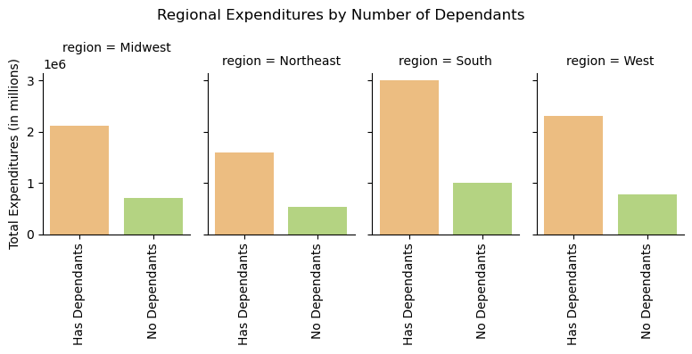

```python
### FacetGrid for dependants and Revenue
dependants_revenue = sns.FacetGrid(dependants_revenue, col="region", height=4, aspect=.5,)
dependants_revenue.map(sns.barplot, "dependants_flag", "prices", palette='RdYlGn', order = ['Has Dependants', 'No Dependants'], ci= None)

dependants_revenue.set_xticklabels(rotation='vertical')
dependants_revenue.set_axis_labels("", "Total Expenditures (in millions)")
dependants_revenue.fig.suptitle("Regional Expenditures by Number of Dependants")
dependants_revenue.figure.subplots_adjust(top=.8)
plt.tight_layout()
```

There are no significant differences across regions in expenditures.

```python
#Export dependants_revenue
dependants_revenue.figure.savefig(os.path.join(path, '04 Analysis', 'Visualizations', 'dependants_revenue'))
```

### Regional Orders

#### Regional Orders by Income Group

```python
#aggregating 'order_id' and 'max_order' from sample
income_orders = ords_prods_cust_dept.groupby(['department', 'income_group','region'], as_index=False).agg({'order_id': 'count', 'max_order': 'sum'})
```

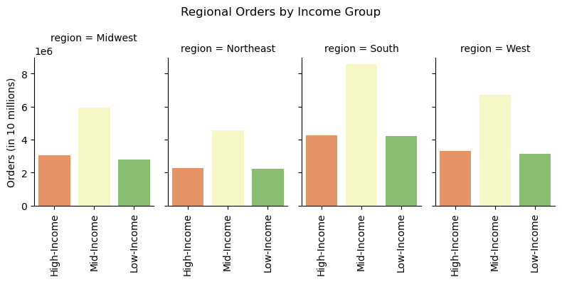

```python
### FacetGrid for income and orders
income_orders = sns.FacetGrid(income_orders, col="region", height=4, aspect=.5,)
income_orders.map(sns.barplot, "income_group", "max_order", palette='RdYlGn', order = ['High-Income', 'Mid-Income', 'Low-Income'], ci= None)

income_orders.set_xticklabels(rotation='vertical')
income_orders.set_axis_labels("", "Orders (in 10 millions)")
income_orders.fig.suptitle("Regional Orders by Income Group")
income_orders.figure.subplots_adjust(top=.8)
plt.tight_layout()
```

There are no significant differences across regions in number of regional orders.

```python
#Export income_orders
income_orders.figure.savefig(os.path.join(path, '04 Analysis', 'Visualizations', 'income_orders'))
```

#### Regional Orders by Age Group

```python
#aggregating 'order_id' and 'max_order' from sample
age_orders = ords_prods_cust_dept.groupby(['department', 'age_group','region'], as_index=False).agg({'order_id': 'count', 'max_order': 'sum'})
```

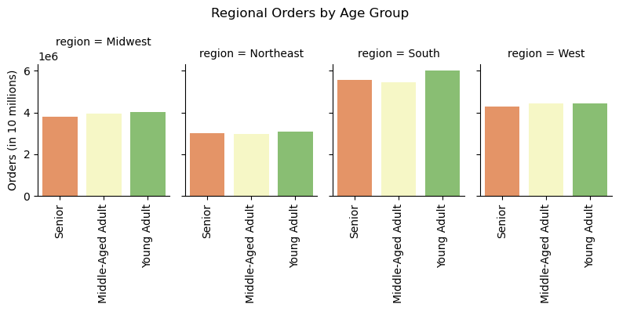

```python
### FacetGrid for income and orders
age_orders = sns.FacetGrid(age_orders, col="region", height=4, aspect=.5,)
age_orders.map(sns.barplot, "age_group", "max_order", palette='RdYlGn', order = ['Senior', 'Middle-Aged Adult', 'Young Adult'], ci= None)

age_orders.set_xticklabels(rotation='vertical')
age_orders.set_axis_labels("", "Orders (in 10 millions)")
age_orders.fig.suptitle("Regional Orders by Age Group")
age_orders.figure.subplots_adjust(top=.8)
plt.tight_layout()
```

There are no significant differences across regions in number of regional orders.

```python
#Export age_orders
age_orders.figure.savefig(os.path.join(path, '04 Analysis', 'Visualizations', 'age_orders'))
```

#### Regional Orders by Dependants

```python
#aggregating 'order_id' and 'max_orders' from sample
dependants_orders = ords_prods_cust_dept.groupby(['department', 'dependants_flag','region'], as_index=False).agg({'order_id':'count', 'max_order': 'sum'})
```

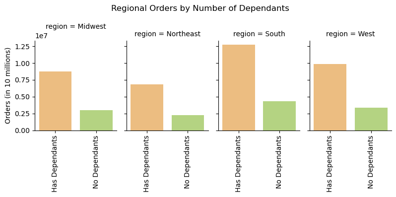

```python
### FacetGrid for dependants and orders
bar_dependants_orders = sns.FacetGrid(dependants_orders, col="region", height=4, aspect=.5,)
bar_dependants_orders.map(sns.barplot, "dependants_flag", "max_order", palette='RdYlGn', order = ['Has Dependants', 'No Dependants'], ci= None)

bar_dependants_orders.set_xticklabels(rotation='vertical')
bar_dependants_orders.set_axis_labels("", "Orders (in 10 millions)")
bar_dependants_orders.fig.suptitle("Regional Orders by Number of Dependants")
bar_dependants_orders.figure.subplots_adjust(top=.8)
plt.tight_layout()
```

There are no significant differences across regions in number of regional orders.

```python
#Export dependants_orders
bar_dependants_orders.figure.savefig(os.path.join(path, '04 Analysis', 'Visualizations', 'dependant_orders'))
```

### Regional Departments

```python
#aggregating 'region' and 'department' from sample
region_department = ords_prods_cust_dept.groupby(['region', 'department'], as_index=False).agg({'order_id': 'count', 'max_order': 'sum'})
```

[figure not shown]

```python
### FacetGrid for region and department
region_department = sns.FacetGrid(region_department, col="department", height=4, aspect=.5,)
region_department.map(sns.barplot, "region", "max_order", palette='RdYlGn', order = ['Northeast', 'Midwest', 'South', 'West'], errorbar=None)

region_department.set_xticklabels(rotation='vertical')
region_department.set_axis_labels("", "Orders")
region_department.fig.suptitle("Regional Orders by Department")
region_department.figure.subplots_adjust(top=.8)
```

There are no significant differences across regions in department orders.

```python
#Export region_department
region_department.figure.savefig(os.path.join(path, '04 Analysis', 'Visualizations', 'region_department'))
```